# ggplot2: 14 Build a plot layer by layer

## 14.5.1 Geoms Exercises

1. Download and print out the ggplot2 cheatsheet from http://www.rstudio.com/resources/cheatsheets/ so you have a handy visual reference for all the geoms.
2. Look at the documentation for the graphical primitive geoms. Which aesthetics do they use? How can you summarise them in a compact form?

Graphical primitives use x and y as the minimum required aesthetics. They have additional optional arguments. geom_blank() geom_curve() geom_path() geom_polygon() geom_rect() geom_ribbon()

Compact form: aes(x,y)

3. What’s the best way to master an unfamiliar geom? List three resources to help you get started.

ggplot cheatsheet google ?functionName for help file RStudio help stack overflow ask/email a friend

4. For each of the plots below, identify the geom used to draw it.

geom_violin() geom_point() with size as aes and alpha = 0.5? geom_hex() geom_jitter() geom_area() geom_path()

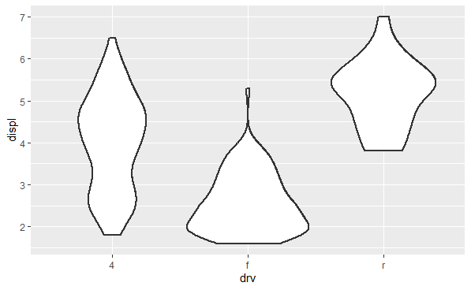

```r
# from YX solution
ggplot(data=mpg,aes(x=drv,y=displ))+
geom_violin(lwd=1)
```

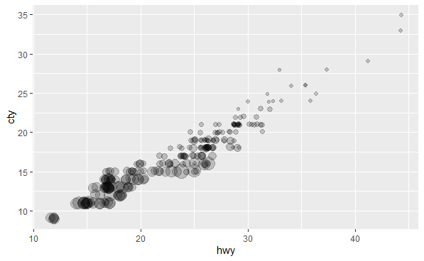

```r
ggplot(data=mpg,aes(x=hwy,y=cty))+
geom_jitter(alpha=0.2,size=mpg$displ,height = 0.1) #??
```

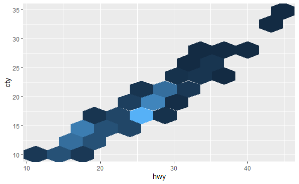

```r
ggplot(data=mpg,aes(x=hwy,y=cty))+
geom_hex(bins=10,show.legend = F)
```

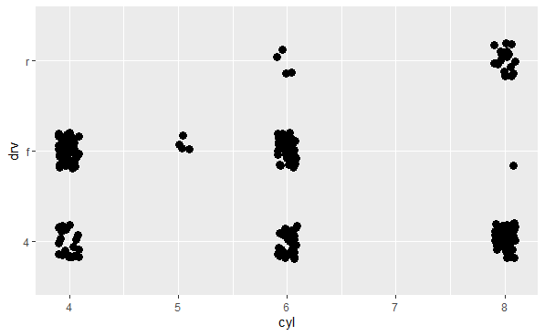

```r
ggplot(data=mpg,aes(x=cyl,y=drv))+
geom_jitter(width = 0.1,height=0.2, size=3)
```

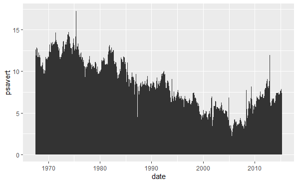

```r
ggplot(data=economics,aes(x=date,y=psavert))+
geom_area()
```

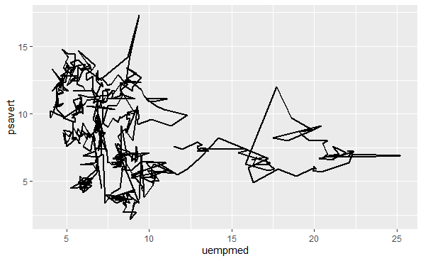

```r
ggplot(data=economics,aes(x=uempmed,y=psavert))+
geom_path(lwd=1)
```

5. For each of the following problems, suggest a useful geom:

-Display how a variable has changed over time. geom_line using time on x axis geom_step geom_area

-Show the detailed distribution of a single variable. geom_histogram geom_violin (geom_point with color aes() ->assuming you have x y coordinates) ) -Focus attention on the overall trend in a large dataset. geom_smooth() over geom_point geom_boxplot or geom_violin

-Draw a map. geom_map() or ggmap() library(bcmaps) has high and low resolution

-Label outlying points. geom_point() on outlier dataset with labels or geom_label() geom_text mapped to outliers geom_points for outliers in bigger halo (biiger size than df)